# Aventure 2 - Github et la visualisation de données numériques

STT-1100 Introduction à la science des données

## 🧊 Mission Antarctique – Dans la peau d’un·e scientifique de données

Bienvenue dans votre nouvelle mission scientifique ! Vous êtes désormais **scientifique de données** dans l’équipe de la **Dre Adélie**, une chercheuse spécialisée dans l’étude des pingouins d’Antarctique. Elle vous a confié un ensemble de données collectées sur le terrain pour l’aider à explorer certaines pistes de recherche.

Votre travail consiste à **manipuler, transformer et visualiser** les données de manière rigoureuse, afin d’en extraire des informations utiles et reproductibles. Vous devrez notamment produire des visualisations convaincantes, calculer des statistiques descriptives et documenter votre démarche dans un rapport clair.

> 🐧 Le jeu de données, qui contient des mesures physiques de plusieurs espèces de pingouins, vous servira de terrain d’enquête.

## ✍️ Déroulement de la mission et livrables attendus

La mission se déroulera en **deux temps**, car la Dre Adélie devra bientôt repartir en expédition en Antarctique.

### 🔹 Partie 1 – Avant le départ de la Dre Adélie

Avant son départ, vous collaborerez étroitement avec elle pour explorer les premières pistes. Elle vous demandera de :

- Nettoyer et transformer les données avec `dplyr`.
- Calculer des statistiques descriptives pertinentes sur les variables numériques.
- Créer des visualisations exploratoires (`ggplot2`) pour mieux comprendre les relations entre les variables.

📘 **Livrable de la première partie** :  
Vous devez rédiger un **journal de bord** dans un rapport Quarto (format HTML) qui documente vos observations, vos explorations et les pistes que vous avez soulevées avec elle. Ce journal sert à garder une trace de vos analyses avant qu’elle ne parte sur le terrain. Un modèle de journal de bord vous sera donné.

### 🔹 Partie 2 – Au retour de la Dre Adélie

De retour de mission, la Dre Adélie reviendra avec des **questions précises** à explorer et vous demandera de l’aider à préparer un rapport solide pour accompagner sa **demande de subvention**.

📘 **Livrable de la deuxième partie** :  
Un **rapport structuré et complet** répondant à ses nouvelles demandes précises, incluant : - Des visualisations ciblées. - Des analyses précises basées sur vos découvertes antérieures. - Une mise en forme professionnelle (titre, légendes, axes lisibles, cohérence graphique). - Un suivi rigoureux via **GitHub**, incluant plusieurs commits bien commentés. - Elle vous donnera une liste de tâches claires et précises à répondre.

> 🧑‍💼 **Note de terrain** : Pendant votre mission, un·e collègue plus expérimenté·e (Jules Tremblay) passera vous voir de temps en temps pour vérifier que tout se passe bien. Il ou elle vous posera quelques **questions rapides** pour tester votre compréhension. Répondez-y sérieusement, ces vérifications vous aideront à consolider vos apprentissages !

# Comment réussir cette aventure

Bienvenue dans cette nouvelle aventure en science des données ! Cette fois, vous allez collaborer avec une chercheuse qui étudie les manchots de la station Palmer en Antarctique. Votre mission est d’explorer et d’analyser ses données pour l’aider à répondre à ses questions scientifiques.

Pour réussir cette aventure, voici quelques conseils essentiels :

- **Lisez attentivement chaque section** avant de passer à l’expérimentation. Les explications fournies vous permettront de bien comprendre les concepts et les outils utilisés.
- **Expérimentez activement** en exécutant le code proposé et en l’adaptant à vos propres analyses. Modifier et tester différentes approches est un excellent moyen d’apprendre.
- **Réfléchissez aux questions posées par la chercheuse** et utilisez les outils adéquats pour y répondre. Pensez à justifier vos choix et interprétations.
- **Soyez rigoureux** dans votre travail en adoptant de bonnes pratiques de programmation et en documentant vos analyses.
- **N’hésitez pas à poser des questions** si vous rencontrez des difficultés ou si certains concepts restent flous.

Cette aventure vous permettra de développer vos compétences en manipulation, visualisation et analyse de données avec `dplyr` et `ggplot2`. Ce sont des compétences primordiales pour un scientifique de données. Prenez le temps d’explorer les différentes étapes et amusez-vous à apprendre !

# 🚀 Travail sur Github

La chercheuse a préparé un dépôt sur GitHub où elle souhaite que vous enregistriez tout votre travail. De son côté, elle y a déposé la base de données qu’elle a collectée ainsi qu’une description détaillée des variables. Elle souhaite notamment que vous completiez un journal de bord modèle au format Quarto.

Avant de commencer l’analyse des données, vous devez récupérer le dépôt GitHub contenant les fichiers nécessaires.

1️⃣ Clonez le dépôt “Aventure-2-IDENTIFIANT_GITHUB”, pour cela créez un nouveau projet Rstudio et copier coller le lien HTTPS de votre repo Github (voir feuille aide mémoire).

💡 Astuce : Si vous souhaitez revenir plus tard sur ce projet, vous pouvez ouvrir directement le projet en double-cliquant sur le fichier `.Rproj` dans votre explorateur de fichiers.

2️⃣ Ouvrir le fichier Quarto de journal de bord: Inscrivez votre nom et enregistrer.

3️⃣ Premier commit et push vers GitHub: Une fois votre fichier `.qmd` modifié et enregistré, commitez et poussez vos modifications sur GitHub :

Attention: on se rappelle que les messages de commit doivent être parlant. Par exemple “Initialisation du journal de bord”

🎯 Félicitations ! Vous êtes maintenant prêt à débuter l’analyse scientifique des manchots ! 🐧🚀

> 💡 Conseil : Utiliser le modèle de journal de bord pour completer l’ensemble des analyses de la première partie de cette aventure. Prenez donc quelques minutes pour regarder la structure du document.

# 📂 Lecture des données

La chercheuse vous a fourni un fichier Excel contenant les données des manchots qu’elle a collectées. Votre première mission consiste à **charger ces données dans R** en utilisant l’interface graphique de RStudio.

**🔹 Étapes à suivre**

1. **Ouvrir le menu d’importation de données**
   - Dans RStudio, allez dans l’onglet **Environment** (Environnement).
   - Cliquez sur **Import Dataset** (Importer un jeu de données).
   - Sélectionnez **From Excel…** (Depuis Excel…), puisque l’extension est un `.xlsx`

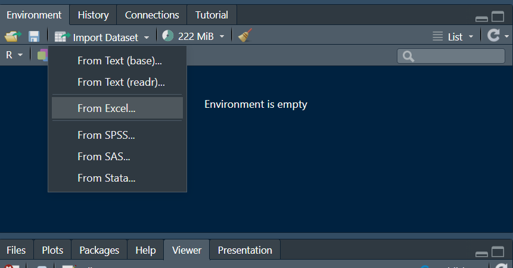

1. **Sélectionner le fichier**
   - Dans la fenêtre qui s’ouvre, cliquez sur **Browse…** (Parcourir…) et sélectionnez le fichier **`.xlsx`** que vous avez téléchargé via le clonage du dépôt.
2. **Ajuster les paramètres d’importation**
   - Assurez-vous que les en-têtes de colonnes sont bien détectées.
   - Vérifiez que toutes les variables sont correctement identifiées (ex. les nombres sont bien en format numérique).
   - On appelera le jeu de données `penguins_mission`, compléter l’information dans la fenêtre.
3. **Importer et afficher les données**
   - Cliquez sur **Import**.
   - Vérifiez que votre jeu de données apparaît dans l’**Environment** sous le nom `penguins_mission`.

   *Remarque*: lorsque on clique sur **Import,** un code s’execute dans la console. Il s’agit du code pour importer le jeu de données.
   - Pour voir un aperçu des données, utilisez la commande suivante dans la console :

     `View(penguins_mission)`

📝 **Rappel : documentez votre importation dans votre rapport Quarto**

Une bonne pratique en science des données est de toujours **documenter** comment vous avez importé les données, même si vous avez utilisé une interface graphique.  
Ajoutez le code exécuté dans la console dans votre fichier **Quarto** de journal de bord **(`.qmd`)** à la section appropriée.

Dans chaque rapport d’analyse, vous devriez avoir une première section **Lecture des données,** avec un bloc de code qui contient le code qui permet de lire les données. J’en profite pour vous rappeler les **bonnes pratiques de programmation du Tidyverse**, à savoir que dans votre bloc de code, il devrait par exemple y avoir des commentaires.

💡 **Pourquoi est-ce important ?**  
Cela garantit que votre analyse est **reproductible** : si un autre chercheur veut la refaire, il pourra exécuter votre code sans avoir à utiliser l’interface graphique.

**🧑‍💼 Intervention de Jules – Nom de la base**

Tu viens d’importer le fichier Excel. Dis-moi, dans quelle variable as-tu stocké les données pour la suite de l’analyse ?  
1. `penguins`  
2. `penguins_mission`  
3. `donnees_manchots`  
4. `mission_antarctique`

**✅ Réponse de Jules**

Tu devais nommer ta base **`penguins_mission`**, comme indiqué dans l’instruction d’importation.  
💡 Attention : tout le reste de l’analyse repose sur ce nom cohérent !

**📌 Une fois vos données chargées, vous êtes prêts à les explorer et à les analyser 🐧! Pensez à générer votre rapport, committer vos modifications et pousser sur GitHub pour garder une trace de votre travail ! 🚀**

# 🛠️ Manipulation de données

## Résumé de données avec `glimpse()`

La chercheuse veut une vue rapide des données pour vérifier leur structure. Utilisez `glimpse()` pour afficher un aperçu :

```r
library(tidyverse)
glimpse(penguins_mission)
```

**🧑‍💼 Jules – Variables numériques**

Combien de **variables numériques** vois-tu dans le `glimpse()` de `penguins_mission`?  
- 3  
- 4  
- 5  
- 6

**✅ Réponse de Jules**

Il y a généralement **5 variables numériques** :  
`bill_length_mm`, `bill_depth_mm`, `flipper_length_mm`, `body_mass_g` et `year`.  
🧠 Attention : certaines versions du jeu peuvent varier selon l’importation !

#### 🔍 Aperçu rapide avec `glimpse()`

La fonction `glimpse()` du package **dplyr** permet d’obtenir **un aperçu rapide et structuré d’un jeu de données**.

Plutôt que d’afficher toutes les lignes ou une structure en arbre comme `str()`, `glimpse()` présente les variables **horizontalement**, avec :

- Le **nom de chaque variable**
- Son **type de données** (`<dbl>`, `<chr>`, `<fct>`, etc.)
- Quelques **valeurs représentatives** de chaque colonne

Cette présentation facilite l’examen rapide de la structure d’un tableau, surtout lorsqu’il comporte **de nombreuses colonnes**.

> 🧠 **Bon à savoir** : `glimpse()` est particulièrement utile pour repérer d’éventuelles erreurs de type (ex. une variable numérique encodée comme texte) ou pour déceler des valeurs manquantes.

**Exercice**

La chercheuse souhaite obtenir un premier compte rendu sur les données disponibles. Pour cela, vous devez compléter le texte suivant et l’intégrer dans votre journal de bord d’analyse Quarto : > “Le jeu de données contient **___** observations et **___** variables. Les variables sont *,* , **___**….etc”

**Note**

💡 **Question de réflexion** : Que se passe-t-il si la chercheuse modifie la base de données ? Par exemple, elle a oublié un manchot et l’ajoute sans vous prévenir, puis met à jour le dépôt GitHub. Lorsque vous réexécutez votre analyse dans votre rapport Quarto (`.qmd`), que va-t-il se passer ? 🤔

Ne vous inquiétez pas si cela vous semble complexe ! Nous reviendrons sur cet aspect plus tard dans la session. 😉

**Exercice**

Combien de variables sont de type numérique? Combien de type charactère? *to-do*: Inclure votre réponse dans votre journal de bord à la suite du texte troué.

**Pensez à générer votre rapport, committer vos modifications et pousser sur GitHub pour garder une trace de votre travail ! 🚀**

## Sélectionner des variables avec `select()`

La chercheuse veut se concentrer uniquement sur certaines variables pertinentes pour son analyse. Utilisez `select()` pour ne garder que `species`, `island`, `bill_length_mm` et `body_mass_g` :

```r
penguins_subset <- penguins_mission %>%
  select(species, island, bill_length_mm, body_mass_g)
```

**Exemple**

Faite un `glimpse()` de la nouvelle base de données `penguins_subset`. Pourquoi avoir choisi un nouveau nom?

**Exercice**

Sélectionnez toutes les variables sauf `flipper_length_mm` et `body_mass_g`. Attention il y a une facon rapide de le faire!

## Créer de nouvelles variables avec `mutate()`

💡 **Explication** : La chercheuse souhaite ajouter une nouvelle colonne indiquant le poids en kilogrammes au lieu de grammes. En effet, son appareil de mesure indiquait les mesures en g, mais elle croit que cela sera plus facile à interpréter en kg.

💡 **Pourquoi est-ce utile ?** Transformer les unités peut faciliter la compréhension et la communication des résultats.

La chercheuse souhaite ajouter une nouvelle colonne indiquant le poids en kilogrammes au lieu de grammes. Utilisez `mutate()` pour créer cette nouvelle variable :

```r
penguins_mission <- penguins_mission %>%
  mutate(body_mass_kg = body_mass_g / 1000)
```

**🧑‍💼 Jules – Masse en kilogrammes**

Tu as transformé la masse en kilogrammes. La masse du penguin numéro 21 est plus petit que 4 kg, vrai ou faux?  
1. Vrai  
2. Faux

**✅ Réponse de Jules**

Quand on regarde la ligne 21 de la base de données, on obtiens un nombre pour `body_mass_kg` de 4.01 kg, donc la réponse est **Faux**.

```r
penguins_mission[21,"body_mass_kg"]
```

On va maintenant continuer avec une nouvelle variable dont la chercheuse est très intéréssée:

**Exercice**

Créez une nouvelle variable appelée `bill_ratio` correspondant au rapport entre la longueur et la profondeur du bec.

🧐 **Question de la chercheuse** : un de mes collègues en antartique m’assure que le rapport **moyen** entre la longueur et la profondeur du bec est superieur à 3. De mon côté, je trouve cela étrange, car ca ne respecte pas ce qu’on peut lire dans la littérature. Peux-tu m’aider avec cela? j’aimerai que tu répondes à la question dans le journal de bord.

**Pensez à générer votre rapport, committer vos modifications et pousser sur GitHub pour garder une trace de votre travail ! 🚀**

## Filtrer les données avec `filter()`

La chercheuse veut analyser uniquement les manchots de l’île **Biscoe**. Utilisez `filter()` pour ne garder que ces observations :

```r
penguins_biscoe <- penguins_mission %>%
  filter(island == "Biscoe")
```

**Exercice**

Filtrez les données pour ne garder que les manchots de l’espèce **Adelie** de l’île Biscoe.

## Regrouper et résumer les données avec `group_by()`

La chercheuse souhaite connaître la masse moyenne des manchots par espèce. Utilisez `group_by()` suivi de `summarise()` pour obtenir cette information :

```r
penguins_summary <- penguins_mission %>%
  group_by(species) %>%
  summarise(mean_body_mass_g = mean(body_mass_g, na.rm = TRUE))
```

*Remarque*: on utilise l’option `na.rm=TRUE` dans les fonctions, ce qui est assez pratique, car cela permet de calculer la statistique en omettant les valeurs manquantes (`NA`).

**Exercice**

🧐 **Question de la chercheuse** : Quelle est la combinaison île/espèce qui possède la longueur médiane de nageoire la plus faible ? j’aimerai que tu répondes à la question dans le journal de bord.

Grâce à `group_by` on peut aussi par exemple filter par groupe, ce qui peut être très pratique!

**Exercice**

📝 **Exercice** : Faites sortir le premier manchot de la base de données pour chaque espèce et chaque île. *Indice:* on peut utiliser la fonction `top_n`.

**Pensez à générer votre rapport, committer vos modifications et pousser sur GitHub pour garder une trace de votre travail ! 🚀**